# 6 Creating Reports in Quarto

Author

Zach Himmelsbach

## 6.1 What is Quarto?

Quarto is the “next-generation” of RMarkdown. Most tutorials on Quarto are intended for people who have experience with RMarkdown, so a great place to start is to read the prior chapter before reading this one.

Once you’re familiar with RMarkdown, the tricks you know will almost always work in Quarto. The major difference is that Quarto will render *inside* RStudio, as you write your document, which makes it a little nicer to work with. There are other new (and very cool) features, but they aren’t essential for anything in this course.

## 6.3 Creating a Quarto Report

[figure not shown]

When you click on “Quarto Document…” RStudio might take a few seconds to load. Then you’ll see this pop-up:

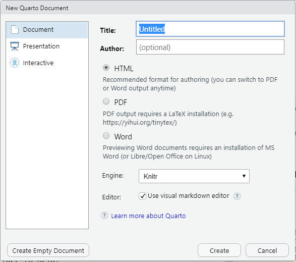

Fill out the document title and author (just like for RMarkdown). You can always change the title and author later. You’ll want to render your reports as PDFs, so select that option. Finally, hit the “Create” button at the bottom.

RStudio will load up a new Quarto doc (with some boilerplate markdown in it). From here, you can treat it like an RMarkdown file.

If you want a more thorough introduction to Quarto, check out [this tutorial.](https://quarto.org/docs/get-started/hello/rstudio.html)

## 6.4 Rendering to PDF

To render your report to PDF, you’ll need to have an installation of LaTex. You can set this up from within RStudio.

Down by your console, there’s a tab called “Terminal.” Click on it to open the terminal. Inside the terminal type the following:  
`quarto install tool tinytex`

I recommend restarting your computer after this.

## 6.5 A Couple Quick Tricks

#### 6.5.0.1 Making Code Chunks

Use the keyboard shortcut `ctrl+alt+i` or `command + option + i` to create a new R code chunk.

#### 6.5.0.2 Adding Images

You can copy-paste or drag-and-drop images into a Quarto doc. That’s how I put the above screenshots into this document.

## 6.6 Additional Quarto Resources

Here are a couple more links if you’d like to learn more:

- The [RMarkdown Cheatsheet](https://posit.co/resources/cheatsheets/?type=posit-cheatsheets&_page=2/) has great information. Remember, most things that work in RMarkdown work in Quarto. Also, there are a lot of other great cheatsheets at this site as well.
- A [Quarto Intro Video](https://www.youtube.com/watch?v=y5VcxMOnj3M) that walks through using Quarto for the first time.
- A [In Depth Quarto Intro](https://www.youtube.com/watch?v=yvi5uXQMvu4) video that covers many amazing new features (like making interactive html reports).